# Green vegetables and figs

Malcolm Ross

## 1. Introduction

Green vegetables form an important part of *tamaji (ch.2, §6.2), the ingredients of a meal which accompany *kanaŋ, starchy food (ch.2, §6.1). Henderson & Hancock (1988: 83) point out that there is often no meat or fish component in the accompanying ingredients in the Solomons, and that these often consist only of green vegetables, which are a major source of protein. This explains the popularity of the high-protein *Abelmoschus manihot*. Solomon Islanders consume a diverse range of green vegetables, some cultivated, some collected from the wild, and the same is true in the Bismarcks.

Probably the most widely cultivated leafy vegetables in the Bismarck Archipelago are *Abelmoschus manihot* (§2.1) and various species of *Amaranthus* (§2.2). However, all the latter except *Amaranthus tricolor* are introduced plants (R.M. Bourke, pers. comm.) and were most probably not present in the gardens of Proto Oceanic speakers. Young leaves and petioles of *Colocasia esculenta* taro (ch.9, §2.2.1) are also commonly eaten as vegetables, and many languages have a separate word for them (ch.4, §2.5).

Ferns recorded as being eaten include species of *Asplenium*, *Athyrium*, *Ctenitis*, *Cyathea* (§3.1), *Dennstaedtia*, Diplazium and *Dryopteris*, as well as *Cyclosorus truncatus* (Paijmans 1976: 125). *Diplazium esculentum* is noted by Henderson & Hancock (1988: 84) as the most widely eaten fern in the Solomons. However, the only fern for which a POc term is reconstructed here is *Cyathea* (§3.1).

An important seasonal food in some areas is the inflorescence (the unopened flower) of *Saccharum edule* (§3.2). Another edible grass, Setaria palmifolia (no reconstruction), is an important vegetable in inland areas of the Bismarcks and New Guinea (M. Bourke, pers. comm.). The stinging herb *Laportea* interrupta (syn. Fleurya interrupta, Urtica interrupta) is cultivated and eaten by the Tolai of the Gazelle Peninsula of New Britain (ch.7, §6.3 .2). The leaves of *Morinda citrifolia* are also eaten as a green vegetable in parts of Papua New Guinea (ch.13, §3.4). Despite the large number of species that serve as green vegetables, however, only a few terms for them have been reconstructed.

Trees of the genus *Ficus* (§4) are included here because leaves of some freestanding species serve as green vegetables in NW Island Melanesia. This is not true of all *Ficus* species in the region, but it is convenient to keep all species of the genus together, as there are difficulties in tying the glosses of some reconstructions down to particular species.

## 2. Leafy vegetables

### 2.1. *Abelmoschus manihot* (syn. *Hibiscus manihot*), slippety cabbage, bush cabbage, island cabbage, TP aibika, P slipari kabis, Bkabis aelan (Malvaceae)

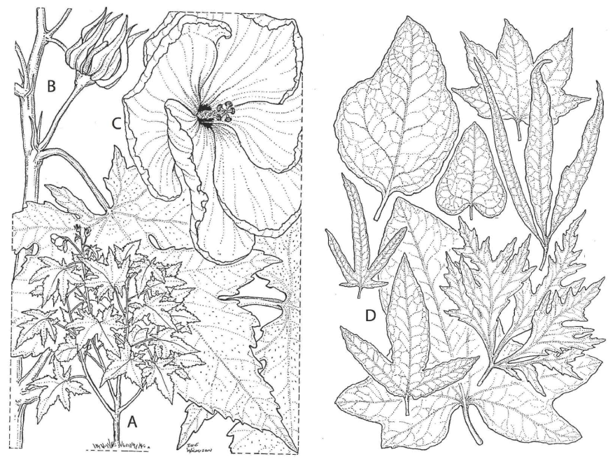

**Figure 10.1:** *Abelmoschus manihot*: **A**, plant (height 1.5 m); **B**, stem with leaf (edible) and flower bud; **C**, flower; **D**, varieties displayed to show the diversity in leaf shape.

*Abelmoschus manihot* is a low, many-branched tree-like shrub, seemingly present in every garden throughout the Bismarck Archipelago and the Solomons (Figure 10.1). Barrau (1955: 77) calls it ‘truly the traditional vegetable of the whole of Melanesia’. Cuttings are planted in mixed crop gardens and are also harvested from young regrowth in abandoned gardens. There are many varieties, the young shoots and leaves of which have a high protein-to-calorie ratio and are cooked in stone ovens, boiled or steamed in bamboo containers or roasted in bark (Paijmans 1976: 124, Hviding 2005: 131).

POc *wasa primarily denoted *Abelmoschus manihot*, evidently the most salient and commonly consumed green vegetable in Lapita communities, but it also appears to have been used hypernymously for ‘green vegetables’ in general, to judge from the glosses below.

| **POc** |  | *wasa | ‘*Abelmoschus manihot*; green vegetables in general’ (French-Wright 1983) |
| --- | --- | --- | --- |
| Adm | Mussau | *wasa* | ‘vine (generic?)’ |
| NNG | Tuam | *(ai)waz* | ‘edible greens, *Gnetum gnemon*’ |
| NNG | Mangap | *(kai)wos* | ‘edible greens, *Gnetum gnemon*’ |
| NNG | Bing | *wās* | ‘*Abelmoschus manihot*’ |
| NNG | Matukar | *wai* | ‘greens’ (Kasprus 1945) |
| NNG | Takia | *wos* | ‘*Abelmoschus manihot*’ |
| NNG | Sissano | *(eyl-)wuas* | ‘*Abelmoschus manihot*’ |
| NNG | Kairiru | *was* | ‘vegetable greens; legumes’ |
| MM | Madak | *vas* | ‘*Abelmoschus manihot*’ |
| MM | Patpatar | *wasa* | ‘fern, *Dryopteris aridis*’ |
| MM | Tangga | *(fun)wes* | ‘*Abelmoschus manihot*’ |
| SES | Arosi | *wata* | ‘herb with edible leaves, *Amaranthus*’ |
| NCV | Mota | *as* | ‘a convolvulus, *Ipomoea* sp.’ |
| **PSV** |  | *nə-was | ‘*Abelmoschus manihot*’ (Lynch 2001c) |
| SV | Kwamera | *nu-vas* | ‘*Abelmoschus manihot*’ |
| SV | Lenakel | *nu-hua* | ‘*Abelmoschus manihot*’ |

French-Wright (1983: 162) also reconstructs a term POc *bele which apparently denoted *Abelmoschus manihot* alone. Geraghty (2004: 85) suspects that the Polynesian terms are borrowed from Fijian, since Fijian *bele* can be glossed as ‘soft leaf’. If, however, the Gedaged, Sye and Ura terms are cognate, this observation is not relevant.

| **POc** |  | *bele | ‘*Abelmoschus manihot*’ (French-Wright 1983) |
| --- | --- | --- | --- |
| NNG | Gedaged | *bel* | ‘shrub like the croton with aromatic dark green leaves’ |
| SV | Sye | *(nta)mple* | ‘*Abelmoschus manihot*’ |
| SV | Ura | *(da)mle* | ‘*Abelmoschus manihot*’ |
| Mic | Kiribatese | *bere* | ‘*Abelmoschus manihot*’ (Polynesian borrowing?) |
| Fij | Wayan | *bele* | ‘taxon including *Abelmoschus manihot* and *Abelmoschus moschatus*’ |
| Fij | Bauan | *bele* | ‘*Abelmoschus manihot*’ |
| Pn | Tongan | *pele* | ‘*Abelmoschus manihot*’ |
| Pn | Samoan | *pele* | ‘*Abelmoschus manihot*’ |

Two terms for *Abelmoschus manihot* can be reconstructed in lower interstage languages.

| **PROc** |  | *sasaRu | ‘*Abelmoschus manihot*’ (Franccois 2004b: Proto Banks *sasar) |
| --- | --- | --- | --- |
| NCV | Vurës | *sasar* | ‘*Abelmoschus manihot*’ |
| NCV | Lemerig | *n-sasar* | ‘*Abelmoschus manihot*’ |
| NCV | Merlav | *na-ssar* | ‘*Abelmoschus manihot*’ |
| Fij | Wayan | *sasau* | ‘wild spinach taxon, bitter tasting, eaten boiled’ |
| Fij | Ba | *sasau* | ‘*Abelmoschus manihot*’ (Preston et al. 1998) |

| **PNCV** |  | *vera | ‘*Abelmoschus manihot*’ (Lynch 2004a) |
| --- | --- | --- | --- |
| NCV | Maewo | *fʷere* | ‘*Abelmoschus manihot*’ (Preston et al. 1998) |
| NCV | Ambae | *were* | ‘*Abelmoschus manihot*’ |
| NCV | Tamambo | *(ha)vera* | ‘*Abelmoschus manihot*’ |
| NCV | Uripiv | *nu-veɾ* | ‘*Abelmoschus manihot*’ |
| NCV | Rerep | *ne-ver* | ‘*Abelmoschus manihot*’ |
| NCV | Lonwolwol | *(faha)ver* | ‘green edible plants or leaves, a general term for native greens’ |

The meaning of the etymon reconstructed below is not clear. It may have been another generic for green vegetables in general or denoted a kind of green vegetable. On the evidence of Lau alone, may have been *Abelmoschus manihot*. It was probably not *Amaranthus viridis*, as this appears to have been unknown to POc speakers.

| **POc** |  | *pʷa(k,g)e | ‘k.o. green vegetable (?)’ |
| --- | --- | --- | --- |
| Adm | Lou | *pʷakɛ* | ‘fern’ |
| Adm | Drehet | *pʷake* | ‘greens; fibrous/stringy, mainly stems after cooking, found wild near water or grown in gardens’ |
| PT | Dobu | *pai* | ‘green foods’ |
| MM | Tolai | *pe-pege* | ‘*Amaranthus viridis*’ |
| SES | Lau | *kʷake* | ‘*Abelmoschus manihot*’ |

### 2.2. *Amaranthus tricolor* (syn. *Amaranthus gangeticus*, *Amaranthus oleraceus*), Chinese spinach, Joseph’s coat amaranth, TP *aupa* (Amaranthaceae)

A number of *Amaranthus* species are grown in New Guinea and the Bismarcks today, but probably only *Amaranthus tricolor*, an ancient introduction from SE Asia, was present traditionally.[^1] Others, mostly Central and South American domesticates, have been introduced by Europeans since 1870 (Bourke forthcoming, Bourke & Allen forthcoming).

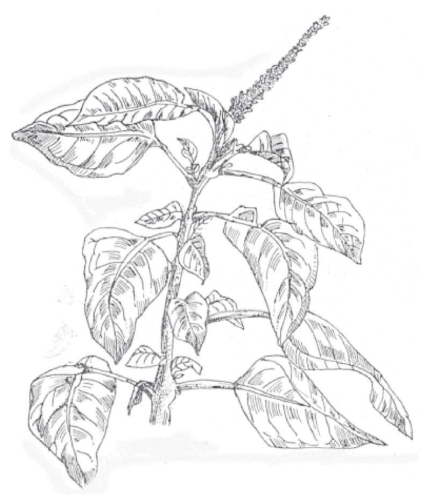

**Figure 10.2:** Aramanthus tricolor, Chinese spinach

*Amaranthus tricolor* is grown from seed in mixed gardens and gathered whole after 1-2 months growth. Some plants are left to go to seed, and the seeds stored for planting. The spinach-like leaves are, like *Abelmoschus manihot*, cooked in stone ovens, boiled or steamed in bamboo containers or roasted in bark (Paijmans 1976: 124-125).

The only reconstruction is at the level of PNCV:

| **PNCV** |  | *keka | ‘cockscomb plant, *Amaranthus tricolor*’ |
| --- | --- | --- | --- |
| NCV | Mota | *ɣeɣa* | ‘cockscomb plant, *Amaranthus* sp.’ |
| NCV | Raga | *gega* | ‘cockscomb plant, *Amaranthus* sp.’ |
| NCV | Apma | *kek* | ‘*Amaranthus tricolor*’ |
| NCV | Namakir | *kek* | ‘tree sp. with green leaf’ |

### 2.3. *Gnetum gnemon*, TP *tulip* (Gnetaceae)

*Gnetum gnemon* is a small tree found in lowland forests in the Bismarcks, the Solomons, Vanuatu and Fiji, growing to between 8 and 15 m in height. Leaf stalks grow directly from the branch in pairs: hence its Tok Pisin name, *tulip* ‘two-leaf’ (Figure 10.3). The young leaves and shoots are widely cooked and eaten as a vegetable. It has red or orange fruit, the seeds and mesocarp of which are roasted and eaten in some areas (Paijmans 1976: 124, Evans 1999: 19-21, Hviding 2005: 139): Evans singles out the islands of the Temotu Province of the Solomons for special mention. In the wild it grows along rivers and streams, but not near the beach, as it appears to dislike salt spray (Manner & Elevitch 2006a). Peekel (1984: 37) describes it as a ‘cultivated tree’ and Kennedy & Clarke (2004) mention it in their list of species that are subject to arboriculture.

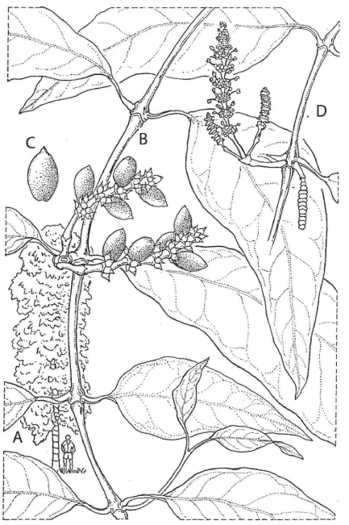

**Figure 10.3:** *Gnetum gnemon*: **A**, tree; **B**, fruiting branch with edible young leaves and fruit; **C**, mature edible fruit; **D**, flowering branch with edible flower.

On New Britain and Manus and in the Siassi Islands the bark fibre of *Gnetum gnemon* is reported as being used to make ropes and string (Floyd 1954, O’Collins & Lamothe 1989, Bugenhagen & Bugenhagen 2007). On Manus the bark is also used as a wrapping material.

POc *kusaq ‘k.o. edible greens’ may have denoted *Gnetum gnemon*, but more widespread reflexes are needed before we can be sure of this. Like the other terms for green vegetables reconstructed in this chapter, reflexes refer to more than one kind of green vegetable.

Misima *kusai* provides evidence for the final *-q of POc *kusaq. Misima has borrowed much of its vocabulary from Suauic dialects: these add paragogic *-i* after a final consonant, and *-i* here points to the earlier presence of *-q.

| **POc** |  | *kusaq | ‘k.o. edible greens’ |
| --- | --- | --- | --- |
| PT | Misima | *kusai* | ‘*Gnetum gnemon*’ |
| PT | Sudest | *uða* | ‘*Gnetum gnemon*’ |
| SES | Kwaio | *ʔuta* | ‘*Abelmoschus manihot*’ |

### 2.4. *Polyscias* spp., panax, B *nalaslas* (Araliaceae)

*Polyscias* species are erect thin shrubs between one and 5 m in height found at least as far east as Fiji. They grow wild in shady environments and have green foliage which is eaten as a green vegetable in New Guinea, the Bismarcks, the Solomons and Vanuatu. In NW Island Melanesia they are often planted (from cuttings) as hedges, but when they are cultivated in sunlight, their appearance changes, as the foliage turns pale green or yellow and cultivated shrubs are often pruned to obtain a thick bushy form. French (1986: 74) names five species growing in Papua New Guinea, namely *Polyscias cumingiana*, *Polyscias scutellaria*, *Polyscias fruticosa*, *Polyscias macgillivrayi* and *Polyscias verticillata*, and Henderson & Hancock (1988: 111-112) list all except the first for the Solomons (Figure 10.4). They comment that the greens have ‘a pleasant mild “curry” taste’.

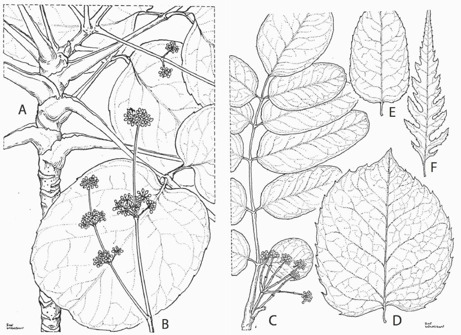

**Figure 10.4:** *Polyscias* species: **A**, *Polyscias scutellaria*, young shoot with small portion of inflorescence; **B**, terminal portion of inflorescence; **C**, *Polyscias verticillata*: flowering shoot and leaf; **D**, *Polyscias fruticosa*: leaflet; **E** and **F**, leaflets of two other *Polyscias* species.

Peekel (1984: 421-422) describes the first three. *Polyscias cumingiana* (syn. *Polyscias pinnata*, *Polyscias rumphiana*) and *Polyscias scutellaria* (syn. *Nothopanax scutellarium*, *Crassula scutellaria*) are tree-like shrubs respectively 2-5m and 3-6m in height, the leaves of which are used for packing fish for cooking and as a green vegetable. Hviding (2005: 122) notes that in Marovo the large green and yellow leaves of *Polyscias cumingiana* are used as ingredient in stews. *Polyscias fruticosa* (syn. *Panax fruticosum*, *Nothopanax fruticosum* ), is a smaller shrub, 0.8-3 m high, with smaller leaves. According to Gardner & Pawley (2006), on Waya juice extracted from the leaves of *Polyscias* was dropped into the nostrils as a cure for earache or headache.

No POc term is unambiguously reconstructable, but it is possible that the reflexes below of PSOc *(la)lawis ‘*Polyscias* sp.’ may be cognate with Muyuw (PT) *(a)lawiluw* (Damon 2004) and Lau (SES) *lausi*, both denoting ‘*Celtis nymanii*’, a small tree used in housebuilding and firewood, the leaves of which provide a cure for rheumatism (Fox 1974, Kwa’ioloa & Burt 2001: 157-158). If so, then POc *lawis, gloss unknown (a tree-like shub or small tree species), would be reconstructable. Lau *lausi* presents a problem, however, as it reflects a form *lawisi with final *-s and echo vowel *-i: this is a canonic NW Solomonic form, and we are forced to postulate borrowing into Lau, where such borrowings do not usually occur.

| **PSOc** |  | *(la)lawis | ‘*Polyscias* sp.’ |
| --- | --- | --- | --- |
| NCV | Neve’ei | *(naŋa)lelav* | ‘*Polyscias* sp.’ |
| NCV | Tape | *a-lap* | ‘*Polyscias* sp.’ |
| NCV | Larëvat | *ne-lav* | ‘*Polyscias* sp.’ |
| SV | Sye | *(i)lawih* | ‘*Polyscias* sp.’ |
| SV | Anejom̃ | *(na-pʷo)jev* | ‘*Polyscias* sp.’ |

| **PNCV** |  | *bei | ‘*Polyscias scutellaria*’ (Lynch 2004a) |
| --- | --- | --- | --- |
| NCV | Ambae | *bei* | ‘*Polyscias* sp.’ |
| NCV | Araki | *pʷe-pʷei* | ‘*Polyscias scutellaria*’ |
| NCV | Raga | *bei* | ‘*Polyscias* sp.’ (Walsh 2004) |
| NCV | Uripiv | *na-bi* | ‘*Polyscias scutellaria*’ |

The items reflecting PNCV *lalaso ‘*Polyscias scutellaria*’ (?) below appear to be cognate with Lau, Kwara’ae (SES) *lalato* ‘*Xylocarpus granatum*’ (ch.6, §4.6). However, they are not cognate in the strict sense. Each set of items reflects an independent innovation entailing reduplication of a reflex of POc *lasoR ‘testicles’. In the case of *Xylocarpus granatum* the comparison is with rounded fruit that hang heavily (Kwa’ioloa & Burt 2001: 122). Explaining PNCV *lalaso is more problematic. Lynch (2004a) glosses the reconstruction ‘*Polyscias* scutellaria’ on the basis of the gloss of its reflexes in Paamese, Lewo, Apma, Nguna and S Efate. However, its denotation in Mota seems to be the aerial yam, *Dioscorea bulbifera* (ch.9, §2.1.3), and it is easy to infer a perceived resemblance between testicles and tubers on the vine. If this inference is correct, then *Dioscorea bulbifera* may have been the PNCV sense of *lalaso, rather than *Polyscias scutellaria*.

| **PNCV** |  | *lalaso | ‘*Polyscias scutellaria*’ (Clark 1996; gloss from Lynch 2004a; ?) |
| --- | --- | --- | --- |
| NCV | Mota | *lalaso* | ‘a kind of half-wild yam, with tubers on the vine’ |
| NCV | Paamese | *lelaso* | ‘*Polyscias scutellaria*’ |
| NCV | Lewo | *(puru)le* | ‘*Polyscias scutellaria*’ |
| NCV | Apma | *lalah* | ‘*Polyscias scutellaria*’ |
| NCV | Namakir | *lalah* | ‘yellow hedge around houses’ |
| NCV | Nguna | *na-lalaso* | ‘*Polyscias scutellaria*’ |
| NCV | South Efate | *na-ulalas* | ‘*Polyscias scutellaria*’ |

## 3. Other green vegetables

### 3.1. *Cyathea* spp., B blakpam (Cyatheaceae)

Among the many ferns eaten in Melanesia, there is just one tree-fern genus for which a putative POc term has been reconstructed. This is PROc *(b,bʷ)ala ‘*Cyathea*’. POc *(b,bʷ)ala is also reconstructed below, but only one cognate has been found outside Remote Oceania: Kove *va-vala* ‘cycad’. This means that we can be reasonably certain that POc *(b,bʷ)ala denoted a tree fern, but we as yet have no way of knowing for certain whether this was a *Cycas* or a *Cyathea*. The most widespread tree-fern in the Bismarcks *Cyathea* contaminans (syn. Alsophila latebrosa), with a stem 5-8 m tall (Peekel 1984: 9), is a good candidate for the denotation of *(b,bʷ)ala, but a better distributed cognate set is needed in order to confirm this. The Nakanai of New Britain ate the fronds of *Cyathea* spp. and used the trunks to make fishing spears (Floyd 1954). On Waya Island (western Fiji) the sap of the young parts of this tree-fern was applied externally to cure headaches, and the scales were used to stuff pillows. The pith of the trunk was eaten as famine food (Gardner & Pawley 2006).

| **POc** |  | *(b,bʷ)ala | ‘tree fern, *Cycas* or *Cyathea* sp.’ |
| --- | --- | --- | --- |
| NNG | Kove | *va-vala* | ‘cycad’ |
| **PROc** |  | *(b,bʷ)ala | ‘*Cyathea* sp.’ |
| NCV | Nguna | *na-pʷala* | ‘a fern’ |
| SV | Sye | *ni-val* | ‘wild coconut, Montgomery palm, *Veitchia arecina*’ |
| Fij | Bauan | *bala-bala* | ‘*Cyathea* spp.’ (Keppel et al. 2005) |
| Fij | Wayan | *bala-bala* | ‘*Cyathea lunulata*’ |
| Fij | Yasawa | *bala-bala* | ‘tree fern, *Cyathea* sp.’ |
| Pn | Niuean | *pala* | ‘fern sp.’ |
| Pn | Niuean | *pala-tao* | ‘fern with huge fronds, *Angiopteris evecta*’ |
| Pn | East Futunan | *pala-pala* | ‘a tree fern’ |
| Pn | West Futunan | *para-fara* | ‘a tree fern’ |
| Pn | Tikopia | *para-para* | ‘a tree fern, *Cyathea* sp.’ |
| Pn | Emae | *bala-bala* | ‘a tree fern’ |
| Pn | Tahitian | *para* | ‘a root eaten in times of scarcity’ |
| Pn | Hawaiian | *pala* | ‘tree fern sp., Marattia douglasii’ |
| Pn | Rarotongan | *para* | ‘a large mountain fern, *Marattia fraxinea*; potato fern *Marattia salicina*’ |
| Pn | Māori | *para* | ‘King fern, *Marattia salicina*’ |

### 3.2. *Saccharum edule*, ‘coastalpitpit’ (in Papua New Guinea), TP, P *pitpit*, B *naviso* (Poaceae)

*Saccharum edule* is a tall grass related to sugarcane (*Saccharum officinarum*). Henderson & Hancock (1988: 101) write, ‘It grows in a variety of locations, but seems best adapted to low altitude, where it can form quite dense stands sometimes attaining heights of four metres or more.’ It is cultivated for the unopened inflorescence (flower) at the tip of the cane, harvested as an important seasonal vegetable which is either roasted in its leafy sheath or cooked in coconut cream with other vegetables (Figure 10.5).

*Saccharum edule* was apparently domesticated long ago, and its several varieties are propagated only by cultivation (Barrau 1962: 157-158). It is grown from cuttings consisting of three or four nodes of the cane, i.e. 30–40 em long, and usually grows in clumps up to two or three metres in height. In Papua New Guinea it is cultivated in gardens up to an altitude of 1800 m. It is also grown in the Solomons, Vanuatu and Fiji.

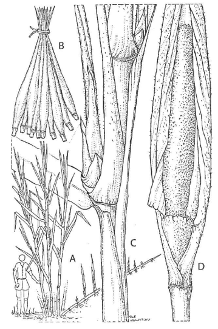

**Figure 10.5:** *Saccharum edule*: **A**, stand of plants; **B**, swollen tips ready for market (ca 50cm long); **C**, stem with suckers; **D**, semi-mature edible inflorescence.

It is possible that Far East Manggarai, Kepo, Waerana, Razong, Rembong (all CMP) *tebor* ‘Saccharum sp.’ (Verheijen 1990: 240) are cognate with the items below. If it is, then PCEMP *tabuqaR is reconstructable and the reconstruction below is elevated to POc.

| **PWOc** |  | *tabuqaR | ‘*Saccharum edule*’ (Pawley 1978: *tabukal) |
| --- | --- | --- | --- |
| NNG | Kove | *tavuhai* | ‘*Saccharum edule*’ (A. Chowning, pers. comm.)[^2] |
| NNG | Malai | *taboɣar* | ‘*Saccharum edule*’ (Lincoln 1976) |
| NNG | Gitua | *tabuar* | ‘*Saccharum edule*’ |
| NNG | Takia | *tabu* | ‘*Saccharum edule*’ |
| NNG | Mapos Buang | *abuχk* | ‘*Saccharum edule*’ |
| PT | Molima | *tabuʔala* | ‘*Saccharum edule*’ |
| PT | Roro | *kapua* | ‘*Saccharum edule*’ |
| MM | Vitu | *tabuɣare* | ‘*Saccharum edule*’ |
| MM | Nakanai | *tabua* | ‘*Saccharum edule*’ |
| MM | Teop | *tabuana* | ‘*Saccharum edule*’ |
| MM | Mono-Alu | *tavuala* | ‘*Saccharum edule*’ (W. McClatchey, pers. comm.) |
| MM | Kia | *tavolohi* | ‘*Saccharum edule*’ (W. McClatchey, pers. comm.) |

cf. also:

| PT | Motu | *tabogana* | ‘wild pitpit’ (for †*tabu(ɣ)a*: apparently borrowed) |
| --- | --- | --- | --- |

## 4. *Ficus* spp., banyans, figs (Moraceae)

### 4.1. Terms for classes of *Ficus*

Worldwide there are about a thousand species of *Ficus*, including the common fig, *F. carica*. Over 500 species occur in the Asia-Pacific region. Many of them have a limited distribution. *Ficus granatum*, for example, is limited to Vanuatu, *Ficus scabra* to Vanuatu, New Caledonia, Fiji, Tonga and Samoa (Walter & Sam 2002: 164, 166). As a consequence, it is difficult to gloss reconstructed terms with their species, as the same term was apparently applied to similar species at different locations. The one distinction that is more easily made is between independently growing species and stranglers.

Independently growing *Ficus* species are usually of medium size, up to about 15 m tall, and often have edible leaves. Strangler figs, however, sometimes grow to 40 m and form part of the forest canopy. A strangler starts its life as an epiphyte high in a tree where a tiny sticky seed has been deposited in animal droppings. The new seedling grows slowly at first, getting nutrients from leaf litter. It sends out thin roots that snake down the trunk of the host tree or dangle as aerial roots from its branches. When the roots reach the ground they dig in and grow aggressively, competing with the host tree for water and nutrients. The roots form a network that encircles the host and fuses together. As the roots grow thicker they squeeze the host’s trunk, cutting off its nutrient supply. In the canopy the strangler’s leaves grow more densely than the host’s, depriving it of sunlight. Eventually the host dies from strangulation, insufficient sunlight and root competition, and the strangler fig stands on its own. If the host rots away, a hollow centre remains.

A salient feature of the genus *Ficus* is its figs, which technically are not fruits. A fig is a ‘false fruit’ or multiple fruit, in which the flowers and seeds grow together to form a single mass. What is commonly called the ‘fruit’ of a fig is a syconium, an almost closed receptacle with many small male and female flowers arranged on the inner surface. Technically, the fruit of a fig is one of the many seed-bearing flowers inside the syconium. The syconium typically has a bulbous shape with a small opening at the distal end that gives access to tiny wasps (Agaoninae spp.) that pollinate the flowers in the process of laying their eggs within the syconium, thus enjoying a symbiotic relationship with the fig tree.

The literature reports numerous instances of the bark, the latex or the leaves of one or other *Ficus* species being used for medicinal purposes. On Vanua Lava (Banks Islands, Vanuatu) latex from *Artocarpus altilis* and *Ficus adenosperma* is mixed as a potion against excessive menstrual discharge (Bourdy & Walter 1994). On Chuuk the bark of *Ficus* prolixa is used as medicine against evil spirits, its fruits and leaves used as medicine, and its roots are used to flavor a special breadfruit pudding (Goodenough & Sugita 1980). On Lihir the leaves are heated and rubbed on painful joints, bones, muscles. They can also be used to heal sickness after eating the wrong kind of fish. They also have ritual power, and are used to make parcels containing several other types of medicinal leaves (S. Foale 2001).

The inner bark of *Ficus* species is used in New Britain for male garments, and old pieces of these are used to bind the heads of children in order to elongate the skull, and for wrapping food for cooking in a stone oven (Arentz et al. 1989: 94, A. Chowning, pers. comm.). However, Mahdi (1999) shows that strangler figs have sacred and ceremonial significance across much of the Austronesian speaking region, including in Oceania at least southern Vanuatu and New Caledonia.

Three POc terms for apparently superordinate *Ficus* taxa are reconstructable: *nunuk, *qayawan and *ba[k,g]a.

POc *nunuk denoted either a taxon including all *Ficus* species known to POc speakers or a taxon including just small freestanding species; it is unclear which. The fact that Peekel does not give Tolai *nunu* as the name for any of the 16 species for which he provides vernacular names implies that it is a generic term for all *Ficus*. On the other hand, the fact that the more carefully specified glosses other than Lou denote small freestanding species (*Ficus aspera*, F. subulata and *Ficus vitiensis*) suggests the latter.

Mahdi (1999) suggests either that *nunuk reflects the same root as that in POc *[qa]nunu ‘shadow’ or that some Oceanic terms for *Ficus* species reflect *[qa]nunu rather than *nunuk, but I see no evidence for either proposal.

| **PMP** |  | *nunuk | ‘banyan, *Ficus benjamina*’ (ACD; Mahdi 1999) |
| --- | --- | --- | --- |
| **POc** |  | *nunuk | ‘fig trees, *Ficus* taxon’ (Ross 1996d) |
| Adm | Lou | *nun* | ‘tree with numerous aerial roots, the banyan’ |
| Adm | Lenkau | *nun* | ‘banyan’ |
| PT | Sudest | *nunu* | ‘edible nut’ |
| MM | Kara (East) | *nunui* | ‘cycad’ (*-i* < POc *-k) |
| MM | Tolai | *nunu* | ‘banyan tree’ |
| MM | Ramoaaina | *nunu* | ‘banyan tree’ |
| MM | Nehan | *nun* | ‘*Ficus* sp.’ |
| MM | Varisi | *nunu(ra)* | ‘*Ficus copiosa*’ (W. McClatchey, pers. comm.) |
| NCV | Maewo | *nunue* | ‘*Ficus aspera*’ (Walter and Sam 2002: 293) [^3] |
| SV | Sye | *(novo)nuɣ* | ‘*Ficus subulata*’ |
| Fij | Bauan | *nunu* | ‘fig tree taxon, including *Ficus vitiensis* and other freestanding species’ (J. Parham 1972: 137-139) |

| **PEMP** |  | *qayawan | ‘banyan tree, *Ficus* sp.’ (Blust 1978a: *ayawan) |
| --- | --- | --- | --- |
| **POc** |  | *qayawan | ‘*Ficus* strangler fig taxon’ (Ross 1996d) |
| **PAdm** |  | *qaiwa | ‘banyan, *Ficus* spp.’ (Blust 1996b) |
| Adm | Wuvulu | *aiwa* | ‘banyan tree’ |
| Adm | Nauna | *kew* | ‘banyan’ |
| Adm | Titan | *yew* | ‘banyan’ |
| SJ | Sobei | *eya* | ‘banyan’ |
| NNG | Amara | *(a)kao* | ‘*Ficus* sp.’ |
| NNG | Gitua | *aiowan* | ‘*Ficus* sp. with short leaf; sometimes chewed with poapoa bark in lieu of betel’ |
| NNG | Gedaged | *aiau* | ‘several spp. of strangler fig, *Ficus*’ |
| NNG | Takia | *ayao* | ‘*Ficus* sp.’ |
| NNG | Numbami | *aiyowana* | ‘banyan’ |
| NNG | Wogeo | *vaiawa* | ‘banyan tree’ |
| NNG | Kairiru | *ayou* | ‘ficus tree’ |
| PT | Muyuw | *(a)gi-gaway* | ‘*Ficus tinctoria* (metathesis < *gayaw)’ |
| PT | Tawala | *kiyaha* | ‘tree type, edible fig’ |
| MM | Kara (East) | *iuan* | ‘*Ficus benjamina*, *F. katabibi* and *F. rebareba*’ |
| MM | Tolai | *kiau, kuiau* | ‘*Ficus benjamina*, *F. katabibi*, *F. rebareba*, *Ficus prolixa*’ (Record 1945: *kuiau* ‘*Flagellaria indica*’) |
| MM | Patpatar | *kiaua* | ‘*Ficus benjamina*, *F. katabibi* and *F. rebareba*’ |
| MM | Babatana | *kanava (pitalata)* | ‘*Ficus copiosa*’ (W. McClatchey, pers. comm.) |
| MM | Nduke | *eana* | ‘*Ficus* spp.’ |
| SV | Kwamera | *(nəsu-)aio* | ‘banyan sp., bark used for tapa cloth’ |
| Mic | Nauruan | *eaeo* | ‘*Ficus prolixa*’ |
| Mic | Kiribatese | *aiao* | ‘*Ficus prolixa*’ |
| Mic | Ponapean | *aiaw* | ‘*Ficus prolixa* var. carolinensis’[^5] |
| Mic | Trukese | *āw* | ‘*Ficus prolixa* var. carolinensis’ |
| Mic | Carolinian | *ao* | ‘banyan tree’ (Christian 1899: 350) |
| **PCP** |  | *qayawa | ‘*Ficus* spp.’ |
| Fij | Bauan | *yaðawa* | ‘banyan tree, *Ficus* sp.’ |
| Fij | Wayan | *āwa* | ‘*Ficus pritchardii*, *Ficus tinctoria*’ |
| Fij | Rotuman | *äeva* | ‘banyan tree’ |
| **PPn** |  | *qawa | ‘banyan tree, *Ficus* prolixa (?)’ |
| Pn | Tongan | *ʔovava* | ‘banyan tree, *Ficus prolixa* and *Ficus obliqua*’ (Whistler 1991b: 99-100) |
| Pn | Niuean | *ovava* | ‘banyan tree, *Ficus prolixa*’ |
| Pn | Emae | *raoa* | ‘banyan’ |
| Pn | Rennellese | *ʔaoa* | ‘banyan, *Ficus* benjamini’ |
| Pn | Tikopia | *āoa* | ‘banyan tree, *Ficus* sp.’ |
| Pn | Samoan | *āoa* | ‘banyan tree, *Ficus prolixa* and *Ficus obliqua*’ (Whistler 2000: 157) |
| Pn | Rarotongan | *aoa* | ‘banyan tree’ |

POc *qayawan also seems to have a second set of reflexes in Micronesia. A putative PMic *kawani ‘*Ficus* sp.’ can be reconstructed. However, the correspondences here - especially the word-final reflexes of *n - indicate that this is an early borrowing via the Caroline Islands from a western Austronesian language.

| Mic | Kosraean | *kɔn(-yɛ)* | ‘banyan tree’ |
| --- | --- | --- | --- |
| Mic | Trukese | *əwə̄r* | ‘*Ficus tinctoria*’ |
| Mic | Puluwatese | *yawann* | ‘banyan’ |
| Mic | Satawalese | *awal* | ‘banyan’ |
| Mic | Woleaian | *gewann* | ‘banyan’ |
| Mic | Ulithian | *howel* | ‘banyan’ |

POc *ba[k,g]a denoted a taxon of freestanding, medium-sized *Ficus* species. Denotata of reflexes include *Ficus nodosa*, *Ficus wassa*, *Ficus prolixa*, *Ficus obliqua*, *Ficus mutabilis* and *Ficus tinctoria*, none of them stranglers. [^6]

The items under ‘cf. also’ are probably not cognate. Three of them point to a term for a nut tree, a species of either *Canarium* or *Terminalia*, but data are insufficient to reconstruct this term. Mahdi (1999) suggests that this term is cognate with Western Malaya-Polynesian terms reflecting a putative *pakat ‘root’.

| **POc** |  | *ba(k,g)a | ‘banyan tree, medium-sized *Ficus* spp., not stranglers’ (Biggs 1965: *baka; Ross 1996d) |
| --- | --- | --- | --- |
| MM | Sursurunga | *pak* | ‘tree sp.’ |
| MM | Patpatar | *paka* | ‘*Ficus nodosa*’ |
| MM | Tolai | *paka* | ‘*Ficus* sp. (Record 1945)’ |
| MM | Roviana | *pako-pako* | ‘*Ficus wassa*’ (Henderson and Hancock 1988: 125) |
| **PROc** |  | *baga | ‘*Ficus* spp.; generic for *Ficus*?’ |
| NCV | Mota | *paka* | ‘banyan, various spp.’ |
| NCV | Araki | *(vi)tᫀaka* | ‘banyan spp.’ |
| NCV | Nduindui | *(vi)v-voɣe* | ‘*Ficus wassa*’ (Walter and Sam 2002: 293) |
| NCV | Raga | *baga* | ‘*Ficus* sp.’ (Walsh 2004) |
| NCV | Lonwolwol | *bak* | ‘banyan’ |
| NCV | Port Sandwich | *na-mbaŋg* | ‘banyan, *Ficus bengalensis*’ |
| NCV | Southeast Ambrym | *veak* | ‘*Ficus wassa*’ (Walter and Sam 2002: 293) |
| NCV | Paamese | *a-veka* | ‘*Ficus* sp.’ |
| NCV | Nguna | *na-paga* | ‘banyan, *Ficus bengalensis*’ |
| NCV | Namakir | *bag* | ‘banyan, *Ficus bengalensis*’ |
| NCV | South Efate | *mpak* | ‘*Ficus* spp.’ |
| SV | Sye | *n-paŋ* | ‘banyan, generic’ |
| SV | Lenakel | *nə-pək* | ‘banyan, generic’ |
| SV | Kwamera | *nə-pek* | ‘banyan, generic’ |
| SV | Anejom̃ | *(n)pak* | ‘banyan’ |
| NCal | Nemi | *(ce)baŋ* | ‘*Ficus mutabilis*’ |
| NCal | Jawe | *(ce)baŋ* | ‘*Ficus mutabilis*’ |
| NCal | Iaai | *bɨk* | ‘*Ficus prolixa*’ |
| Fij | Wayan | *baka* | ‘banyan taxon, including *Ficus obliqua*, *Ficus prolixa* and *Ficus tinctoria*’ |
| Fij | Bauan | *baka* | ‘*Ficus obliqua*’ |

cf. also:

| Adm | Mussau | *paka* | ‘*Terminalia catappa*’ |
| --- | --- | --- | --- |
| Adm | Mussau | *baga(laim)* | ‘large variety of Malay apple, *Syzygium* gomata’ |
| Adm | Titan | *baga-bak* | ‘tree sp. with nut-like fruit’ |
| MM | Tolai | *baga* | ‘*Canarium mehenbethene* (Record 1945)’ |

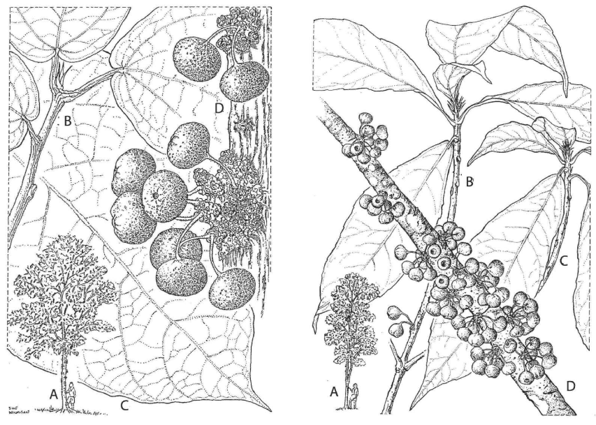

**Figure 10.6:** **Left** *Ficus copiosa*: **A**, tree; **B**, shoot with leaves; **C**, leaf; **D**, figs on trunk. **Right** *Ficus* wassa: **A**, tree; **B**, shoot showing leaf arrangement and figs on stem; **C**, young shoot with edible leaves; **D**, fruit on lower branch.

### 4.2. *Ficus copiosa* and *Ficus wassa*, sandpaper cabbage, sandpaper fig, TP *kumu musong* (Moraceae)

*Ficus copiosa* and *Ficus wassa* are similar (Figure 10.6). Both rejoice in the name ‘sandpaper cabbage’ in the Solomons because of their coarse texture (even when cooked). The leaves of *Ficus wassa* are more abrasive than those of *Ficus copiosa*, and therefore somewhat less popular as food (Henderson & Hancock 1988: 123, 125)

*Ficus copiosa* (syn. *F. longipedunculata*, *F. acanthrophylla*) has twigs covered in bristles (Peekel 1984: 141). It grows widely in New Guinea, the Bismarcks and the Solomons. In Marovo *Ficus copiosa* is traditionally an important leaf vegetable, and young leaves and shoots are either cooked in coconut cream or mixed with crushed smoked *Canarium* nuts (Hviding 2005: 138).

*Ficus wassa* (syn. *F. portus-finschii*, *F. papus* (Peekel), *F. uauasie* (Peekel) is a tree 5-20 m tall with twigs that are hairy and pungent and figs that turn red when ripe (Peekel 1984: 141). It is found from eastern Indonesia through New Guinea, the Bismarcks and the Solomons to Vanuatu (Walter & Sam 2002: 168). The leaves of the wild trees are cooked as a vegetable in Papua New Guinea, the Solomons and Vanuatu (Henderson & Hancock 1988: 125, Wheatley 1992: 170–172). In Vanuatu green figs are eaten cooked. Figs ripen quickly, and must be eaten immediately. Lactating women regularly eat the leaves, which are said to stimulate milk production (Walter & Sam 2002: 168-169).

There is enough agreement among the meanings of reflexes of POc *iguRa to suggest that it had sandpapery leaves and denoted either *Ficus copiosa* or *Ficus wassa* or both.

| **POc** |  | *iguRa | ‘*Ficus* species with sandpapery leaves, either *Ficus copiosa* or *Ficus wassa* or both’ (Chowning 2001) |
| --- | --- | --- | --- |
| MM | Nakanai | *igura* | ‘*Ficus* sp. with sandpapery leaves’ |
| MM | Patpatar | *ikur-kur* | ‘*Ficus* gut’ |
| PT | Bwaidoga | *(a)ikula* | ‘banyan’ |
| PT | Motu | *igula(ra)* | ‘*Ficus* sp.’ |
| SES | Bugotu | *igula* | ‘sandpaper cabbage, *Ficus wassa*’ (Henderson and Hancock 1988: 125) |
| SES | Kwaio | *igula* | ‘tree sp., leaves of which are used to polish wood’ |

POc *pʷabosi is the most likely candidate for a term denoting *Ficus wassa*. All named reflexes denote a small or medium-sized freestanding *Ficus* sp. The set below, from which I tentatively reconstruct POc *pʷabosi, contains some doublets and a number of phonological irregularities, especially in regard to the bilabials. I infer that the two POc bilabials were not identical, but that assimilation has operated to make them so in several reflexes. Doublets are probably the outcomes of local borrowings. An interstage ancestral to Solos, Petats and probably Teop replaced the initial bilabial obstruent with *u-.

| **POc** |  | *pʷabosi | ‘freestanding small or medium-sized *Ficus* sp., probably *Ficus wassa*’ |
| --- | --- | --- | --- |
| NNG | Bing | *bubōs* | ‘wild fig tree (poor quality wood)’ |
| MM | Nakanai | *vovosi* | ‘*Ficus* sp., with edible leaves’ (*-v-* for †*-b-*) |
| MM | Kara (East) | *[ka]pavus* | ‘small *Ficus* sp., *Ficus wassa*’ (Peekel 1984: 141) |
| MM | Patpatar | *habos* | ‘*Ficus pachystemon*’[^7] |
| MM | Patpatar | *papus* | ‘*Ficus wassa*’ |
| MM | Tolai | *papu(-kubar)* | ‘*Ficus wassa*’ |
| MM | Tolai | *uauai(na)* | ‘*Ficus pachystemon*’ (Holdsworth 1975b) |
| MM | Nehan | *boh* | ‘*Ficus* spp.’ |
| MM | Solos | *uabos* | ‘*Ficus* sp.’ (Holdsworth 1977: Noupan village) |
| MM | Petats | *uabos* | ‘*Ficus* sp.’ |
| MM | Teop | *ivoi* | ‘*Ficus* sp.’ |
| MM | Teop | *poi* | ‘*Ficus* sp.’ |
| **PSOc** |  | *(b(a,o))bosi | ‘*Ficus* sp.’ (Lynch 2004a) |
| NCV | Mwotlap | *no-woh* | ‘*Ficus aspera*’ |
| NCV | Apma | *wowos* | ‘*Ficus wassa*’ |
| **PSV** |  | *na-bVbosi | ‘*Ficus* sp.’ (Lynch 2004a) |
| SV | Kwamera | *nu-kʷesi* | ‘fig sp.’ |
| SV | Anejom̃ | *ne-ppaθ* | ‘*Ficus* sp.’ |
| NCal | Nemi | *bo* | ‘banyan sp. without aerial roots’ |
| NCal | Jawe | *bo* | ‘banyan sp. without aerial roots’ |

POc *qa(l,R)a may have been another term for *Ficus copiosa* (§4.2).

| **PMP** |  | *qaRaʔ | ‘*Ficus* spp.’ (Blust 1986) |
| --- | --- | --- | --- |
| **POc** |  | *qa(l,R)a | ‘*Ficus* sp.’ |
| NNG | Gedaged | *ala* | ‘tree sp.’ |
| MM | Nakanai | *kaloli* | ‘*Ficus* sp., probably *Ficus copiosa*’ (A. Chowning, pers. comm.) |
| MM | Tolai | *kala-kala, kaka* | ‘*Ficus copiosa*’ |
| MM | Patpatar | *kala-kala* | ‘*Ficus copiosa*’ |
| MM | Roviana | *kala-la* | ‘banyan, *Ficus* sp.’ |
| MM | Marovo | *kala-la* | ‘banyan, *Ficus* spp.’ |
| SES | To’aba’ita | *θala* | ‘*Ficus variegata*’ |

### 4.3. *Ficus tinctoria*, dye fig (Moraceae)

*Ficus tinctoria* is an erect shrub 2-4 m tall with yellow-orange or red edible figs, found on coral rocks and cliffs on the foreshore or inland in coral soil. It is distributed from India and China through SE Asia, New Guinea and right through the islands as far as western Polynesia, but is absent from New Caledonia (Peekel 1984: 147, Walter & Sam 2002: 169). Its leaves are a green vegetable in Papua New Guinea (Bourke n.d.).

POc *taŋa appears to have denoted *Ficus tinctoria*. This is its meaning in New Ireland. In southern Vanuatu it denotes *Ficus granatum*, another medium-sized freestanding species with edible figs, limited in its distribution to Vanuatu (Walter & Sam 2002: 163-164).

| **POc** |  | *taŋa | ‘*Ficus tinctoria*’ |
| --- | --- | --- | --- |
| MM | Kara (East) | *taŋa* | ‘*Ficus tinctoria*’ |
| MM | Patpatar | *(saŋa)taŋa* | ‘*Ficus tinctoria*’ |
| MM | Tolai | *taŋa(tata)* | ‘*Ficus tinctoria*’ |

| **PSV** |  | *na-təŋ | ‘*Ficus* sp.’ (Lynch 2004a) |
| --- | --- | --- | --- |
| SV | Sye | *na-toŋ* | ‘*Ficus granatum*’ |
| SV | Lenakel | *na-reŋ* | ‘*Ficus granatum*’ |
| SV | Kwamera | *ne-rəŋ* | ‘k.o. tree with stinging leaves’ |
| SV | Anejom̃ | *na-teŋ* | ‘*Ficus adenosperma*’ |

POc *(c,j)api appears to have denoted a species with edible leaves, possibly *Ficus tinctoria*.

| **PMP** |  | *jabi | ‘*Ficus* sp.’ (Blust 1972b) |
| --- | --- | --- | --- |
| **POc** |  | *(c,j)api | ‘*Ficus* sp.’ (Ross 1996d) |
| NNG | Mapos Buang | *dɛ̄v* | ‘*Ficus* sp.; the leaftips are eaten’ |
| Fij | Bauan | *savi(rewa)* | ‘*Ficus tinctoria*’ |

### 4.4. Other names for *Ficus* species

The reconstructions below denote *Ficus* species, but it is not usually certain which one(s).

It is possible that POc *seRa denoted *Ficus adenosperma*, a freestanding tree 5-15 m tall with green or yellow figs that are eaten in times of food shortage in some communities (Peekel 1984: 147; Walter & Sam 2002: 169).

| **POc** |  | *seRa | ‘*Ficus* sp., perhaps *Ficus adenosperma*’ |
| --- | --- | --- | --- |
| Adm | Mussau | *si* | ‘*Ficus* sp.’ |
| MM | Patpatar | *sera* | ‘*Ficus adenosperma*’ |
| MM | Tolai | *ere* | ‘*Ficus adenosperma*’ |
| MM | Nehan | *her* | ‘*Ficus* sp.’ |

POc *bauRa may have denoted a species of strangler fig.

| **POc** |  | *bauRa | ‘*Ficus* sp.’ (perhaps a strangler fig) |
| --- | --- | --- | --- |
| NNG | Mapos Buang | *báuk* | ‘*Ficus* sp.’ |
| SES | Lau | *baola* | ‘banyan’ |
| SES | Kwara’ae | *baola* | ‘strangler fig, *Ficus microcarpa*’ |

The glosses give no real clue to the denotatum of POc *ka(mʷa)-kamʷa, other than that it was perhaps a freestanding species.

| **POc** |  | *ka(mʷa)-kamʷa | ‘*Ficus* sp., perhaps *Ficus nodosa*’ |
| --- | --- | --- | --- |
| PT | Misima | *ka-kamʷa* | ‘k.o. tree, with small, rounded, light green leathery leaves and white and motley-coloured bark and small, fig-shaped fruit.’ |
| MM | Madak | *kem-kem* | ‘*Ficus nodosa*’ |
| SES | Santa Ana | *kamʷa-kamʷa* | ‘sandpaper cabbage, *Ficus wassa*’ |

The gloss of PNCV *buliva is clearly *Ficus* scabra (a species found only in central and souther Vanuatu, New Caledonia, Fiji and western Polynesia; Walter & Sam 2002: 166), but the denotation of PEOc *bulipa remains unclear.

| **PEOc** |  | *bulipa | ‘*Ficus* sp.’ (Clark 1996: PNCV *buliva) |
| --- | --- | --- | --- |
| SES | Kwara’ae | *bu-bulia* | ‘*Ficus austrina*’ |
| **PNCV** |  | *buliva | ‘*Ficus scabra*’ |
| NCV | Mota | *puliva* | ‘a climbing *Ficus*; the leaves cooked and eaten’ |
| NCV | Apma | *bʷilip* | ‘*Ficus scabra*’ (Walter and Sam 2002) |
| NCV | Maewo | *gʷiliva* | ‘*Ficus scabra*’ (Walter and Sam 2002) |
| NCV | Raga | *buliva* | ‘*Ficus* sp.’ |
| NCV | Uripiv | *bʷiliw* | ‘*Ficus scabra*, *Ficus* septica’ |
| NCV | Lonwolwol | *bulva* | ‘wild cotton, burau tree’ |
| NCV | Lewo | *(puru)piliva* | ‘*Ficus scabra*’ (Walter and Sam 2002) |
| NCV | Nguna | *na-puliva* | ‘sycamore’ |
| NCV | Namakir | *na-biliv* | ‘*Ficus scabra*’ (Walter and Sam 2002) |
| NCV | South Efate | *na-plip* | ‘*Ficus granatum*’ |

| **PSOc** |  | *rivu-rivu | ‘small or medium-sized freestanding *Ficus* sp.’ (Lynch 2004a) |
| --- | --- | --- | --- |
| NCV | Ambae | *(va)rivu* | ‘nambalanggo, i.e. *Ficus wassa*’ |
| NCV | Raga | *revrevo* | ‘*Ficus obliqua*’ (Walsh 2004) |
| NCV | Uripiv | *awɾaw* | ‘*Ficus tinctoria*’ |
| SV | Sye | *na-revrep* | ‘*Ficus obliqua*’ |
| SV | Kwamera | *(kʷa)ruviru* | ‘*Ficus* sp.’ |
| SV | Anejom̃ | *ne-rere* | ‘*Ficus obliqua*’ |

## Notes

[^1]: The antiquity in New Guinea of A. dubius, also of SE Asian origin, is unknown; Bourke & Allen forthcoming.
[^2]: In her publications Chowning cites the alternant *tavuahi*.
[^3]: Walter and Sam gloss this as ‘*Ficus adenosperma*’ in their appendix of vernacular names. This seems to be an editorial error, as *Ficus aspera* is the species described in the body of the book (161- 162).
[^4]: *F. katabibi* and *F. rebareba* are Peekel’s temporary names: I have found them nowhere else in the literature.
[^5]: Bender et al. (1983) use the gloss *F. carolinensis*, but Defilipps et al. (1988) list this as a variety of *Ficus prolixa*.
[^6]: *Ficus obliqua* may be freestanding or a strangler. *Ficus bengalensis* (if it is correctly identified), is a recent introduction.
[^7]: One of these forms, probably papus, is presumably a borrowing.